# 第十三章 Matplotlib库

### 13.1.3 柱形图

【1】简单柱形图

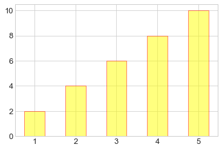

```python
x = np.arange(1, 6)
plt.bar(x, 2*x, align="center", width=0.5, alpha=0.5, color='yellow', edgecolor='red')
plt.tick_params(axis="both", labelsize=13)
```

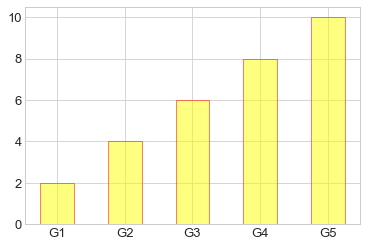

```python
x = np.arange(1, 6)
plt.bar(x, 2*x, align="center", width=0.5, alpha=0.5, color='yellow', edgecolor='red')
plt.xticks(x, ('G1', 'G2', 'G3', 'G4', 'G5'))
plt.tick_params(axis="both", labelsize=13)
```

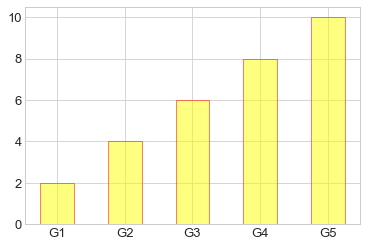

```python
x = ('G1', 'G2', 'G3', 'G4', 'G5')
y = 2 * np.arange(1, 6)
plt.bar(x, y, align="center", width=0.5, alpha=0.5, color='yellow', edgecolor='red')
plt.tick_params(axis="both", labelsize=13)
```

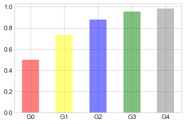

```python
x = ["G"+str(i) for i in range(5)]
y = 1/(1+np.exp(-np.arange(5)))

colors = ['red', 'yellow', 'blue', 'green', 'gray']
plt.bar(x, y, align="center", width=0.5, alpha=0.5, color=colors)
plt.tick_params(axis="both", labelsize=13)
```

【2】累加柱形图

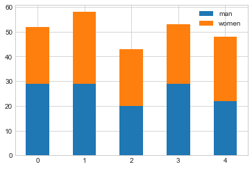

```python
x = np.arange(5)
y1 = np.random.randint(20, 30, size=5)
y2 = np.random.randint(20, 30, size=5)
plt.bar(x, y1, width=0.5, label="man")
plt.bar(x, y2, width=0.5, bottom=y1, label="women")
plt.legend()
```

【3】并列柱形图

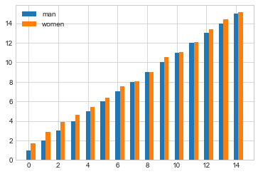

```python
x = np.arange(15)
y1 = x+1
y2 = y1+np.random.random(15)
plt.bar(x, y1, width=0.3, label="man")
plt.bar(x+0.3, y2, width=0.3, label="women")
plt.legend()
```

【4】横向柱形图

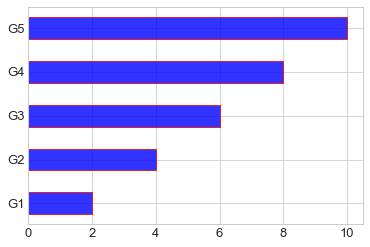

```python
x = ['G1', 'G2', 'G3', 'G4', 'G5']
y = 2 * np.arange(1, 6)
plt.barh(x, y, align="center", height=0.5, alpha=0.8, color="blue", edgecolor="red")
plt.tick_params(axis="both", labelsize=13)
```

### 13.1.4 多子图

【1】简单多子图

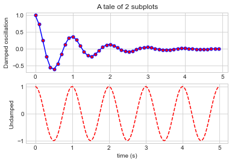

```python
def f(t):
    return np.exp(-t) * np.cos(2*np.pi*t)

t1 = np.arange(0.0, 5.0, 0.1)
t2 = np.arange(0.0, 5.0, 0.02)

plt.subplot(211)
plt.plot(t1, f(t1), "bo-", markerfacecolor="r", markersize=5)
plt.title("A tale of 2 subplots")
plt.ylabel("Damped oscillation")

plt.subplot(212)
plt.plot(t2, np.cos(2*np.pi*t2), "r--")
plt.xlabel("time (s)")
plt.ylabel("Undamped")
```

【2】多行多列子图

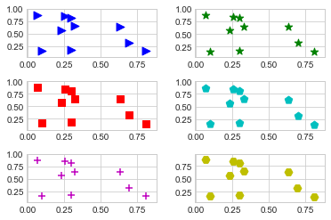

```python
x = np.random.random(10)
y = np.random.random(10)

plt.subplots_adjust(hspace=0.5, wspace=0.3)

plt.subplot(321)
plt.scatter(x, y, s=80, c="b", marker=">")

plt.subplot(322)
plt.scatter(x, y, s=80, c="g", marker="*")

plt.subplot(323)
plt.scatter(x, y, s=80, c="r", marker="s")

plt.subplot(324)
plt.scatter(x, y, s=80, c="c", marker="p")

plt.subplot(325)
plt.scatter(x, y, s=80, c="m", marker="+")

plt.subplot(326)
plt.scatter(x, y, s=80, c="y", marker="H")
```

【3】不规则多子图

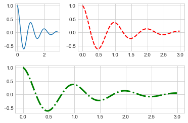

```python
def f(x):
    return np.exp(-x) * np.cos(2*np.pi*x)


x = np.arange(0.0, 3.0, 0.01)
grid = plt.GridSpec(2, 3, wspace=0.4, hspace=0.3)

plt.subplot(grid[0, 0])
plt.plot(x, f(x))

plt.subplot(grid[0, 1:])
plt.plot(x, f(x), "r--", lw=2)

plt.subplot(grid[1, :])
plt.plot(x, f(x), "g-.", lw=3)
```

### 13.1.5 直方图

【1】普通频次直方图

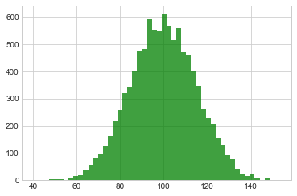

```python
mu, sigma = 100, 15
x = mu + sigma * np.random.randn(10000)

plt.hist(x, bins=50, facecolor='g', alpha=0.75)
```

【2】概率密度

```
(0, 0.03)
```

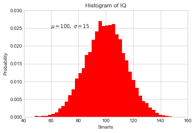

```python
mu, sigma = 100, 15
x = mu + sigma * np.random.randn(10000)

plt.hist(x, 50, density=True, color="r")
plt.xlabel('Smarts')
plt.ylabel('Probability')
plt.title('Histogram of IQ')
plt.text(60, .025, r'$\mu=100,\ \sigma=15$')
plt.xlim(40, 160)
plt.ylim(0, 0.03)
```

```
(0, 0.03)
```

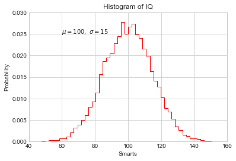

```python
mu, sigma = 100, 15
x = mu + sigma * np.random.randn(10000)

plt.hist(x, bins=50, density=True, color="r", histtype='step')
plt.xlabel('Smarts')
plt.ylabel('Probability')
plt.title('Histogram of IQ')
plt.text(60, .025, r'$\mu=100,\ \sigma=15$')
plt.xlim(40, 160)
plt.ylim(0, 0.03)
```

```
(0, 0.03)
```

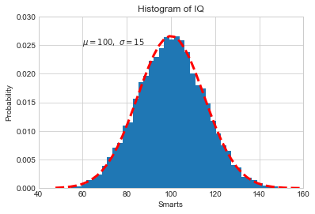

```python
from scipy.stats import norm
mu, sigma = 100, 15
x = mu + sigma * np.random.randn(10000)

_, bins, __ = plt.hist(x, 50, density=True)
y = norm.pdf(bins, mu, sigma)
plt.plot(bins, y, 'r--', lw=3)
plt.xlabel('Smarts')
plt.ylabel('Probability')
plt.title('Histogram of IQ')
plt.text(60, .025, r'$\mu=100,\ \sigma=15$')
plt.xlim(40, 160)
plt.ylim(0, 0.03)
```

【3】累计概率分布

```
(0, 1.1)
```

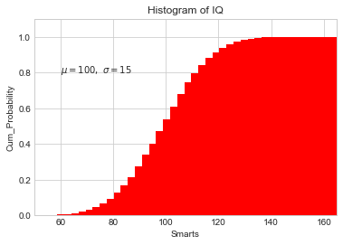

```python
mu, sigma = 100, 15
x = mu + sigma * np.random.randn(10000)

plt.hist(x, 50, density=True, cumulative=True, color="r")
plt.xlabel('Smarts')
plt.ylabel('Cum_Probability')
plt.title('Histogram of IQ')
plt.text(60, 0.8, r'$\mu=100,\ \sigma=15$')
plt.xlim(50, 165)
plt.ylim(0, 1.1)
```

【例】模拟投两个骰子

```python
class Die():
    "模拟一个骰子的类"

    def __init__(self, num_sides=6):
        self.num_sides = num_sides

    def roll(self):
        return np.random.randint(1, self.num_sides+1)
```

- 重复投一个骰子

```
(0, 7)
```

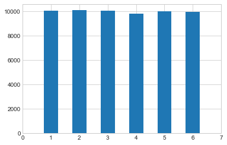

```python
die = Die()
results = []
for i in range(60000):
    result = die.roll()
    results.append(result)

plt.hist(results, bins=6, range=(0.75, 6.75), align="mid", width=0.5)
plt.xlim(0 ,7)
```

- 重复投两个骰子

[output not shown]

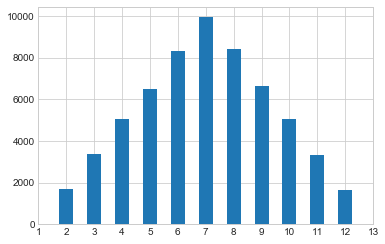

```python
die1 = Die()
die2 = Die()
results = []
for i in range(60000):
    result = die1.roll()+die2.roll()
    results.append(result)

plt.hist(results, bins=11, range=(1.75, 12.75), align="mid", width=0.5)
plt.xlim(1 ,13)
plt.xticks(np.arange(1, 14))
```

### 13.1.6 误差图

【1】基本误差图

```
<ErrorbarContainer object of 3 artists>
```

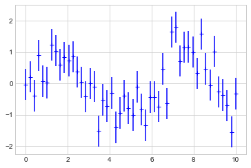

```python
x = np.linspace(0, 10 ,50)
dy = 0.5
y = np.sin(x) + dy*np.random.randn(50)

plt.errorbar(x, y , yerr=dy, fmt="+b")
```

【2】柱形图误差图

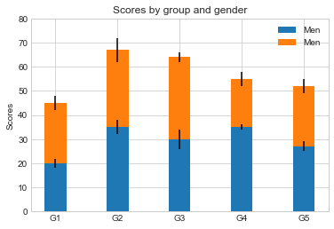

```python
menMeans = (20, 35, 30, 35, 27)
womenMeans = (25, 32, 34, 20, 25)
menStd = (2, 3, 4, 1, 2)
womenStd = (3, 5, 2, 3, 3)
ind = ['G1', 'G2', 'G3', 'G4', 'G5']
width = 0.35

p1 = plt.bar(ind, menMeans, width=width, label="Men", yerr=menStd)
p2 = plt.bar(ind, womenMeans, width=width, bottom=menMeans, label="Men", yerr=womenStd)

plt.ylabel('Scores')
plt.title('Scores by group and gender')
plt.yticks(np.arange(0, 81, 10))
plt.legend()
```

### 13.1.7 面向对象的风格简介

【例1】 普通图

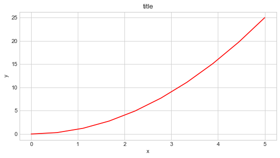

```python
x = np.linspace(0, 5, 10)
y = x ** 2

fig = plt.figure(figsize=(8,4), dpi=80)        # 图像
axes = fig.add_axes([0.1, 0.1, 0.8, 0.8])      # 轴 left, bottom, width, height (range 0 to 1)

axes.plot(x, y, 'r')
axes.set_xlabel('x')
axes.set_ylabel('y')
axes.set_title('title')
```

【2】画中画

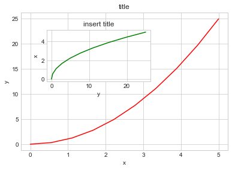

```python
x = np.linspace(0, 5, 10)
y = x ** 2

fig = plt.figure()

ax1 = fig.add_axes([0.1, 0.1, 0.8, 0.8])
ax2 = fig.add_axes([0.2, 0.5, 0.4, 0.3])

ax1.plot(x, y, 'r')

ax1.set_xlabel('x')
ax1.set_ylabel('y')
ax1.set_title('title')

ax2.plot(y, x, 'g')
ax2.set_xlabel('y')
ax2.set_ylabel('x')
ax2.set_title('insert title')
```

【3】 多子图

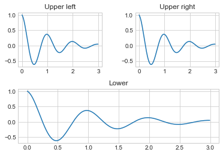

```python
def f(t):
    return np.exp(-t) * np.cos(2*np.pi*t)


t1 = np.arange(0.0, 3.0, 0.01)

fig= plt.figure()
fig.subplots_adjust(hspace=0.4, wspace=0.4)

ax1 = plt.subplot(2, 2, 1)
ax1.plot(t1, f(t1))
ax1.set_title("Upper left")

ax2 = plt.subplot(2, 2, 2)
ax2.plot(t1, f(t1))
ax2.set_title("Upper right")

ax3 = plt.subplot(2, 1, 2)
ax3.plot(t1, f(t1))
ax3.set_title("Lower")
```

### 13.1.8 三维图形简介

【1】三维数据点与线

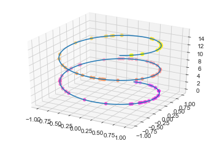

```python
from mpl_toolkits import mplot3d

ax = plt.axes(projection="3d")
zline = np.linspace(0, 15, 1000)
xline = np.sin(zline)
yline = np.cos(zline)
ax.plot3D(xline, yline ,zline)

zdata = 15*np.random.random(100)
xdata = np.sin(zdata)
ydata = np.cos(zdata)
ax.scatter3D(xdata, ydata ,zdata, c=zdata, cmap="spring")
```

【2】三维数据曲面图

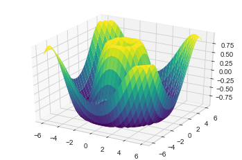

```python
def f(x, y):
    return np.sin(np.sqrt(x**2 + y**2))

x = np.linspace(-6, 6, 30)
y = np.linspace(-6, 6, 30)
X, Y = np.meshgrid(x, y)
Z = f(X, Y)

ax = plt.axes(projection="3d")
ax.plot_surface(X, Y, Z, cmap="viridis")
```

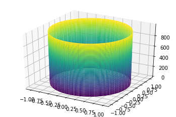

```python
import numpy as np
import matplotlib.pyplot as plt
from mpl_toolkits import mplot3d

t = np.linspace(0, 2*np.pi, 1000)
X = np.sin(t)
Y = np.cos(t)
Z = np.arange(t.size)[:, np.newaxis]

ax = plt.axes(projection="3d")
ax.plot_surface(X, Y, Z, cmap="viridis")
```

## 13.2 Seaborn库-文艺青年的最爱

【1】Seaborn 与 Matplotlib

Seaborn 是一个基于 matplotlib 且数据结构与 pandas 统一的统计图制作库

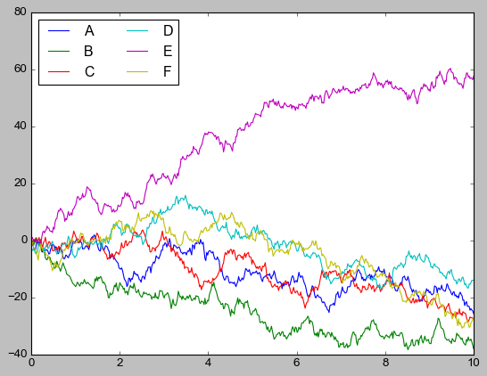

```python
x = np.linspace(0, 10, 500)
y = np.cumsum(np.random.randn(500, 6), axis=0)

with plt.style.context("classic"):
    plt.plot(x, y)
    plt.legend("ABCDEF", ncol=2, loc="upper left")
```

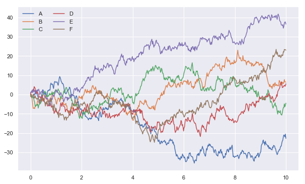

```python
import seaborn as sns

x = np.linspace(0, 10, 500)
y = np.cumsum(np.random.randn(500, 6), axis=0)
sns.set()
plt.figure(figsize=(10, 6))
plt.plot(x, y)
plt.legend("ABCDEF", ncol=2, loc="upper left")
```

【2】柱形图的对比

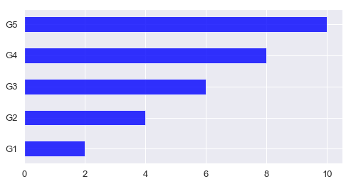

```python
x = ['G1', 'G2', 'G3', 'G4', 'G5']
y = 2 * np.arange(1, 6)

plt.figure(figsize=(8, 4))
plt.barh(x, y, align="center", height=0.5, alpha=0.8, color="blue")
plt.tick_params(axis="both", labelsize=13)
```

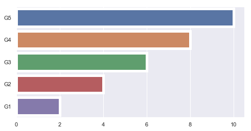

```python
import seaborn as sns

plt.figure(figsize=(8, 4))
x = ['G5', 'G4', 'G3', 'G2', 'G1']
y = 2 * np.arange(5, 0, -1)
#sns.barplot(y, x)
sns.barplot(y, x, linewidth=5)
```

```python
sns.barplot?
```

【3】以鸢尾花数据集为例

```python
iris = sns.load_dataset("iris")
```

```python
iris.head()
```

|  | sepal_length | sepal_width | petal_length | petal_width | species |
| --- | --- | --- | --- | --- | --- |
| 0 | 5.1 | 3.5 | 1.4 | 0.2 | setosa |
| 1 | 4.9 | 3.0 | 1.4 | 0.2 | setosa |
| 2 | 4.7 | 3.2 | 1.3 | 0.2 | setosa |
| 3 | 4.6 | 3.1 | 1.5 | 0.2 | setosa |
| 4 | 5.0 | 3.6 | 1.4 | 0.2 | setosa |

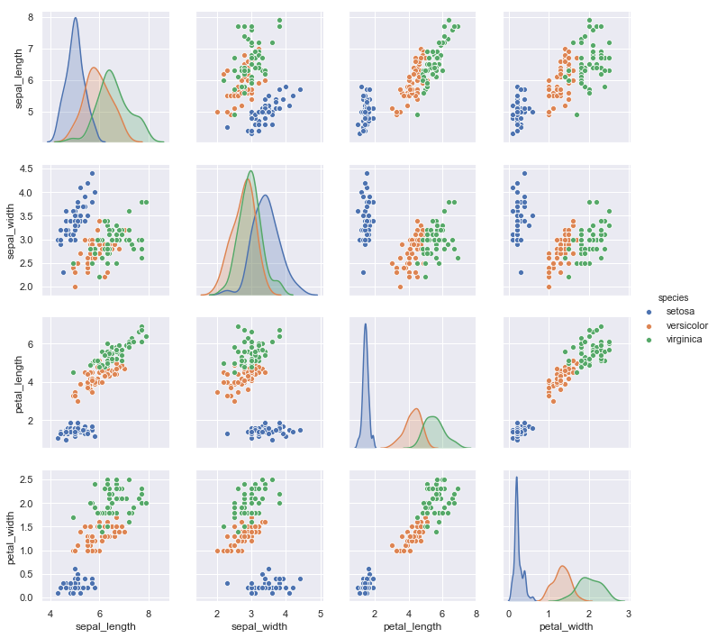

```python
sns.pairplot(data=iris, hue="species")
```

## 13.3 Pandas 中的绘图函数概览

```python
import pandas as pd
```

【1】线形图

```python
df = pd.DataFrame(np.random.randn(1000, 4).cumsum(axis=0),
                  columns=list("ABCD"),
                  index=np.arange(1000))
df.head()
```

|  | A | B | C | D |
| --- | --- | --- | --- | --- |
| 0 | -1.311443 | 0.970917 | -1.635011 | -0.204779 |
| 1 | -1.618502 | 0.810056 | -1.119246 | 1.239689 |
| 2 | -3.558787 | 1.431716 | -0.816201 | 1.155611 |
| 3 | -5.377557 | -0.312744 | 0.650922 | 0.352176 |
| 4 | -3.917045 | 1.181097 | 1.572406 | 0.965921 |

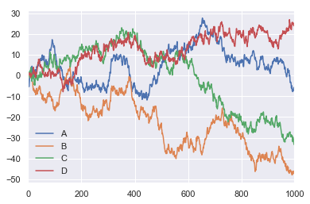

```python
df.plot()
```

```python
df = pd.DataFrame()
df.plot?
```

【2】柱形图

```python
df2 = pd.DataFrame(np.random.rand(10, 4), columns=['a', 'b', 'c', 'd'])
df2
```

|  | a | b | c | d |
| --- | --- | --- | --- | --- |
| 0 | 0.587600 | 0.098736 | 0.444757 | 0.877475 |
| 1 | 0.580062 | 0.451519 | 0.212318 | 0.429673 |
| 2 | 0.415307 | 0.784083 | 0.891205 | 0.756287 |
| 3 | 0.190053 | 0.350987 | 0.662549 | 0.729193 |
| 4 | 0.485602 | 0.109974 | 0.891554 | 0.473492 |
| 5 | 0.331884 | 0.128957 | 0.204303 | 0.363420 |
| 6 | 0.962750 | 0.431226 | 0.917682 | 0.972713 |
| 7 | 0.483410 | 0.486592 | 0.439235 | 0.875210 |
| 8 | 0.054337 | 0.985812 | 0.469016 | 0.894712 |
| 9 | 0.730905 | 0.237166 | 0.043195 | 0.600445 |

- 多组数据竖图

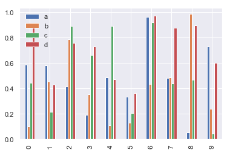

```python
df2.plot.bar()
```

- 多组数据累加竖图

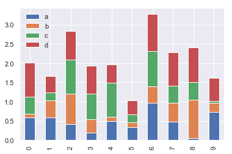

```python
df2.plot.bar(stacked=True)
```

- 多组数据累加横图

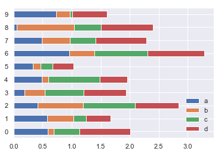

```python
df2.plot.barh(stacked=True)
```

【3】直方图和密度图

```python
df4 = pd.DataFrame({"A": np.random.randn(1000) - 3, "B": np.random.randn(1000),
                     "C": np.random.randn(1000) + 3})
df4.head()
```

|  | A | B | C |
| --- | --- | --- | --- |
| 0 | -4.250424 | 1.043268 | 1.356106 |
| 1 | -2.393362 | -0.891620 | 3.787906 |
| 2 | -4.411225 | 0.436381 | 1.242749 |
| 3 | -3.465659 | -0.845966 | 1.540347 |
| 4 | -3.606850 | 1.643404 | 3.689431 |

- 普通直方图

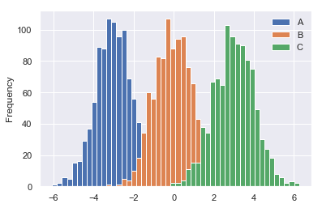

```python
df4.plot.hist(bins=50)
```

- 累加直方图

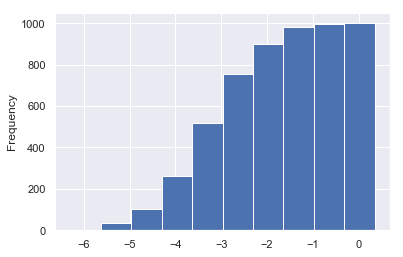

```python
df4['A'].plot.hist(cumulative=True)
```

- 概率密度图

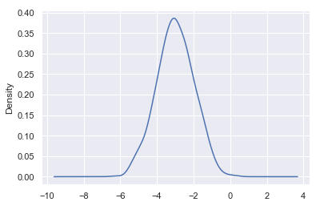

```python
df4['A'].plot(kind="kde")
```

- 差分

```python
df = pd.DataFrame(np.random.randn(1000, 4).cumsum(axis=0),
                  columns=list("ABCD"),
                  index=np.arange(1000))
df.head()
```

|  | A | B | C | D |
| --- | --- | --- | --- | --- |
| 0 | -0.277843 | -0.310656 | -0.782999 | -0.049032 |
| 1 | 0.644248 | -0.505115 | -0.363842 | 0.399116 |
| 2 | -0.614141 | -1.227740 | -0.787415 | -0.117485 |
| 3 | -0.055964 | -2.376631 | -0.814320 | -0.716179 |
| 4 | 0.058613 | -2.355537 | -2.174291 | 0.351918 |

```
array([[<matplotlib.axes._subplots.AxesSubplot object at 0x000002053942A6A0>,
      dtype=object)
```

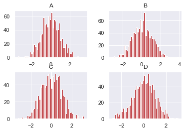

```python
df.diff().hist(bins=50, color="r")
```

```python
df = pd.DataFrame()
df.hist?
```

【4】散点图

```python
housing = pd.read_csv("housing.csv")
housing.head()
```

|  | longitude | latitude | housing_median_age | total_rooms | total_bedrooms | population | households | median_income | median_house_value | ocean_proximity |
| --- | --- | --- | --- | --- | --- | --- | --- | --- | --- | --- |
| 0 | -122.23 | 37.88 | 41.0 | 880.0 | 129.0 | 322.0 | 126.0 | 8.3252 | 452600.0 | NEAR BAY |
| 1 | -122.22 | 37.86 | 21.0 | 7099.0 | 1106.0 | 2401.0 | 1138.0 | 8.3014 | 358500.0 | NEAR BAY |
| 2 | -122.24 | 37.85 | 52.0 | 1467.0 | 190.0 | 496.0 | 177.0 | 7.2574 | 352100.0 | NEAR BAY |
| 3 | -122.25 | 37.85 | 52.0 | 1274.0 | 235.0 | 558.0 | 219.0 | 5.6431 | 341300.0 | NEAR BAY |
| 4 | -122.25 | 37.85 | 52.0 | 1627.0 | 280.0 | 565.0 | 259.0 | 3.8462 | 342200.0 | NEAR BAY |

```
[-125, -113.5, 32, 43]
```

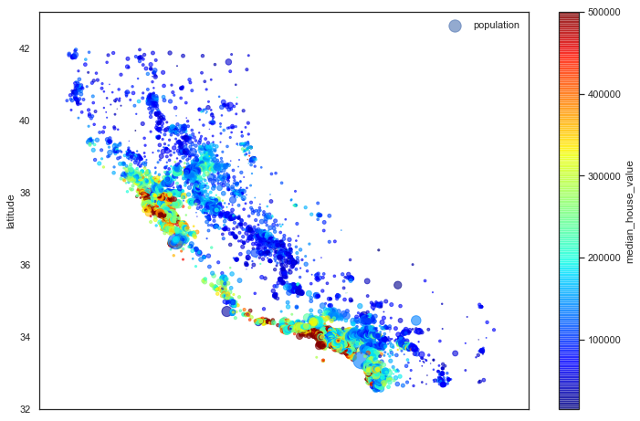

```python
"""基于地理数据的人口、房价可视化"""
# 圆的半价大小代表每个区域人口数量(s),颜色代表价格(c),用预定义的jet表进行可视化
with sns.axes_style("white"):
    housing.plot(kind="scatter", x="longitude", y="latitude", alpha=0.6,
                 s=housing["population"]/100, label="population",
                 c="median_house_value", cmap="jet", colorbar=True, figsize=(12, 8))
plt.legend()
plt.axis([-125, -113.5, 32, 43])
```

[output not shown]

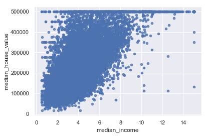

```python
housing.plot(kind="scatter", x="median_income", y="median_house_value", alpha=0.8)
```

【5】多子图

```python
df = pd.DataFrame(np.random.randn(1000, 4).cumsum(axis=0),
                  columns=list("ABCD"),
                  index=np.arange(1000))
df.head()
```

|  | A | B | C | D |
| --- | --- | --- | --- | --- |
| 0 | -0.134510 | 0.364371 | -0.831193 | -0.796903 |
| 1 | 0.130102 | 1.003402 | -0.622822 | -1.640771 |
| 2 | 0.066873 | 0.126174 | 0.180913 | -2.928643 |
| 3 | -1.686890 | -0.050740 | 0.312582 | -2.379455 |
| 4 | 0.655660 | -0.390920 | -1.144121 | -2.625653 |

- 默认情形

```
array([<matplotlib.axes._subplots.AxesSubplot object at 0x0000020539BF46D8>,
      dtype=object)
```

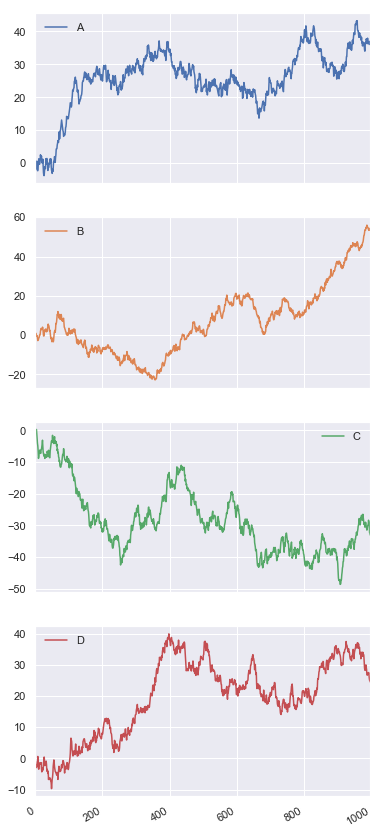

```python
df.plot(subplots=True, figsize=(6, 16))
```

- 设定图形安排

```
array([[<matplotlib.axes._subplots.AxesSubplot object at 0x000002053D9C2898>,
      dtype=object)
```

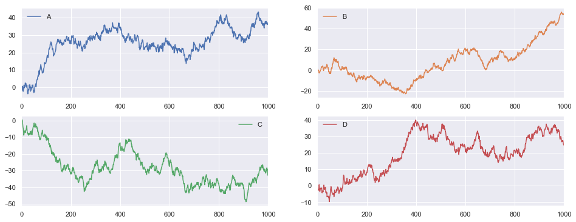

```python
df.plot(subplots=True, layout=(2, 2), figsize=(16, 6), sharex=False)
```

其他内容请参考Pandas中文文档

https://www.pypandas.cn/docs/user_guide/visualization.html#plot-formatting